# Project C: Data Sharing in the Social Sciences in the late 20th Century

# R Studio API Code

```r
# comment out when knitting the file
#setwd(dirname(rstudioapi::getActiveDocumentContext()$path))
```

# Data Importing and Cleaning

## The dataset

Data were from Pienta and Lyle (2009) on data sharing in the social sciences. The overall goal of the project was to find variables related to data sharing attitudes and activities. Researchers surveyed principal investigators of social science awards made by the National Science Foundation (NSF) and the National Institutes of Health (NIH) between 1985 and 2001 was conducted by the Inter-university Consortium for Political and Social Research (ICPSR) from May 2009 to August 2009. The survey consisted of questions about the research data collected, various methods for sharing research data, attitudes and behaviors about data sharing, and demographic information. A total of 1,217 responses were received. After excluding principal investigators that did not collect primary research data and excluding principal investigators of dissertation awards, the final sample size is 1,021. More information can be found in the ‘docs’ directory of this R project. There you will find the project description, codebook, and the survey.

This dataset was chosen due to the growing trend in data sharing. I wanted to understand predictors of data sharing attitudes and data sharing behaviors. This might illuminate reasons associated with eventual data sharing, which is an important open science practice in my opinion.

There 100+ variables included in the dataset that could be related to data sharing attitudes and behaviors. With that many potential predictors, it would be beneficial to use machine learning from a large set of variables.

Let’s import the data and coerce all variables to lowercase for readability.

```r
load("../data/29941-0001-Data.rda")
df = da29941.0001
colnames(df) = tolower(colnames(df))
```

Let’s reorder and rename variables to names that are more descriptive.

```r
# reorder
df = df %>%
  mutate(
    year  = as.ordered(year),
    duration = as.ordered(duration),
    var7  = as.ordered(var7),
    var30 = as.ordered(var30),
    var31 = as.ordered(var31),
    var32 = as.ordered(var32),
    var33 = as.ordered(var33),
    var34 = as.ordered(var34),
    var35 = as.ordered(var35),
    var36 = as.ordered(var36),
    var37 = as.ordered(var37),
    var50 = as.ordered(var50),
    var51 = as.ordered(var51),
    var52 = as.ordered(var52),
    var53 = as.ordered(var53),
    var55 = as.ordered(var55),
    var56 = as.ordered(var56),
    var57 = as.ordered(var57),
    var58 = as.ordered(var58),
    var59 = as.ordered(var59),
    var60 = as.ordered(var60),
    var61 = as.ordered(var61),
    var62 = as.ordered(var62),
    var67 = as.ordered(var67),
    var68 = as.ordered(var68),
    var69 = as.ordered(var69),
    var70 = as.ordered(var70),
    var78 = as.ordered(var78),
    var80 = as.ordered(var80),
    var84 = as.ordered(var84)
  )

# rename
df = df %>%
  rename(
    collect_for_grant = var4,
    num_requests = var7,
    data_available = var9,
    data_personal_website = var12,
    data_prof_website = var13,
    data_prof_archive = var14,
    data_institute_repo = var15,
    data_journal_website = var16,
    data_request = var17,
    data_available_other = var18,
    access_coinvestigator = var21,
    access_grad_student_grant = var22,
    access_grad_student_other = var23,
    access_researcher_institute = var24,
    access_researcher_discipline = var25,
    access_researcher_other = var26,
    access_other = var27,
    barrier_grant_no_interest = var30,
    barrier_grant_prep_data_docs = var31,
    barrier_grant_misinterpret_data = var32,
    barrier_grant_prep_data_time = var33,
    barrier_grant_confidentiality = var34,
    barrier_grant_icf_lang = var35,
    barrier_grant_irb = var36,
    barrier_grant_scooping = var37,
    num_pubs_grant = var40_coded,
    num_pubs_grant_student_author = var41_coded,
    num_pubs_grant_total = var43_coded,
    num_pubs_grant_total_student_author = var44_coded,
    num_pubs_grant_total_unaffiliated = var46_coded,
    num_pubs_grant_total_unaffil_student_author = var47_coded,
    data_available_important = var50,
    data_available_freq = var51,
    data_important_archive = var52,
    data_available_freq_archive = var53,
    barrier_no_interest = var55,
    barrier_prep_data_docs = var56,
    barrier_misinterpret_data = var57,
    barrier_prep_data_time = var58,
    barrier_confidentiality = var59,
    barrier_icf_lang = var60,
    barrier_irb = var61,
    barrier_scooping = var62,
    barrier_other = var63,
    discipline_specific = var66_coded,
    data_available_important_others = var67,
    data_available_freq_others = var68,
    data_important_archive_others = var69,
    data_available_freq_archive_others = var70,
    num_grant_public = var73_coded,
    num_grant_private = var74_coded,
    num_grant_other = var75_coded,
    num_grant_produced_data = var76_coded,
    grant_award_academic_rank = var78,
    grant_award_tenure = var79,
    academic_rank = var80,
    gender = var82,
    race_white = var83_1,
    race_black = var83_2,
    race_hispanic = var83_3,
    race_asian = var83_4,
    race_island = var83_5,
    race_arabic = var83_6,
    race_indigenous = var83_7,
    education = var84,
    education_us = var85,
    education_year = var86_coded,
    age = var87_coded,
    age_at_award = ageataward,
    faculty_status = facstatus,
    discipline_general = discipline,
    discipline_social_science = socsci
  )
```

Let’s explore missingness in the variables.

|  | variable | n_miss | pct_miss |
| --- | --- | --- | --- |
| 1 | pi_title_2 | 984 | 96.3761018609207 |
| 2 | archived | 980 | 95.9843290891283 |
| 3 | var27_dyn_coded | 980 | 95.9843290891283 |
| 4 | var26_dyn_coded | 909 | 89.0303623898139 |
| 5 | var53_dyn_coded | 824 | 80.7051909892263 |
| 6 | var24_dyn_coded | 815 | 79.8237022526934 |
| 7 | var25_dyn_coded | 804 | 78.7463271302644 |
| 8 | amount_awarded | 738 | 72.2820763956905 |
| 9 | var23_dyn_coded | 704 | 68.9520078354554 |
| 10 | pi_title_1 | 586 | 57.3947110675808 |

[output cut: 99 more lines]

Let’s explore missingness in cases.

|  | case | n_miss | pct_miss |
| --- | --- | --- | --- |
| 1 | 434 | 75 | 68.8073394495413 |
| 2 | 44 | 74 | 67.8899082568807 |
| 3 | 137 | 74 | 67.8899082568807 |
| 4 | 471 | 74 | 67.8899082568807 |
| 5 | 825 | 74 | 67.8899082568807 |
| 6 | 845 | 74 | 67.8899082568807 |
| 7 | 874 | 74 | 67.8899082568807 |
| 8 | 892 | 74 | 67.8899082568807 |
| 9 | 303 | 73 | 66.9724770642202 |
| 10 | 356 | 73 | 66.9724770642202 |

[output cut: 1011 more lines]

The rough cutoff I’m comfortable with is 70% missingness in either variables or cases. There are more precise metrics for assessing missingness (e.g., [Madley-Dowd et al., 2019](https://doi.org/10.1016/j.jclinepi.2019.02.016)). However, because estimating these metrics have substantial computational costs, and missingness is not the focus of the current project, I will go with the basic percent missing as a cutoff.

Seeing as there were no cases with over 70% missingness, I dropped only variables over the threshold.

```r
# drop variables with over 70% missingness
var_miss_70 = df %>%
  miss_var_summary %>%
  filter(pct_miss > 70) %>%
  select(variable)

df_miss = df %>%
  select(-unlist(var_miss_70))
```

I dropped conditional “yes/no” variables because those variables are missing not at random. I also discovered that all variables with “masked” as a level has near-zero or zero variance. I’ll be dropping those shortly when preprocessing.

```r
# drop conditional (ie. MNAR) variables
df_drop = df_miss %>%
  select(-str_subset(names(df_miss), "yn"))

# label rownames from case id
df_drop = column_to_rownames(df_drop, "caseid")
```

# Analysis

## Data wrangling

Let’s convert factors to numerics and preprocess.

```r
# convert to numeric
df_num = df_drop
for(i in seq_along(df_num)) {
  df_num[,i] = as.numeric(df_num[,i])
}

# preprocess
df_pp = preProcess(df_num, c("medianImpute","zv","nzv"))

# get features
df_fts = predict(df_pp, df_num)
```

Once we have preprocessed features, let’s dummy code nominal categorical variables.

```r
# get data frame of unordered factors
ordered = c()
for(i in seq_along(df_drop)){
  ordered[i] = !is.ordered(df_drop[,i])
}
df_ordered = df_drop[,ordered]

# get data frame of numeric variables
numeric = c()
for(i in seq_along(df_ordered)){
  numeric[i] = is.numeric(df_ordered[,i])
}
df_factors = df_ordered[,!numeric]

# get variables to dummy code (i.e., unordered factors and non-numeric variables)
dum_names = names(df_factors)

# match dummy variables to what is in the features data frame
# df_fts %in% dum_names
# match(names(df_fts),dum_names)

# dummy code categorical variables to make new features
df_fts = df_fts %>%
  dummy_cols(select_columns = dum_names,
             ignore_na = F,
  ) %>%
  clean_names()
```

If we want to predict overall **data sharing attitudes**, I’ll need to take the average of the following:

- **data_available_important** (“How important is it to you to make your data available for others to use for their own research purposes?”)
- **data_available_important_others** (“How important do you think making data available for others to use for research purposes is to others in your discipline or field?”)
- **data_important_archive** (“How important is placing your data in a professional data archive?”)
- **data_important_archive_others** (“How important do you think it is to others in your discipline to place their data in a professional data archive?”)

I’m also interested in overall **data sharing behaviors** (as opposed to what’s required by grant-awarding agencies), so I’ll take an average of the following:

- **data_available_freq** (“How often have you made your data available to others to use for their own research purposes?”)
- **data_available_freq_others** (“How often do you think others in your discipline make their data available for others to use for their own research purposes?”)
- **data_available_freq_archive** (“How often have you placed your data in a professional archive?”)
- **data_available_freq_archive_others** (“How often do you think others in your discipline place their data in a professional data archive?”)

After getting means, I’ll drop the variables from the dataset. If they aren’t dropped, they would suck up the most variance, and I’m interested in those variables anymore.

```r
# create data sharing attitudes dv
df_fts = df_fts %>%
  rowwise() %>%
  mutate(data_sharing_attitudes =
           mean(
             c(
               data_available_important,
               data_available_important_others,
               data_important_archive,
               data_important_archive_others
             )
           )
  ) %>%
  select(-data_available_important,
         -data_available_important_others,
         -data_important_archive,
         -data_important_archive_others)

# create data sharing behaviors dv
df_fts = df_fts %>%
  rowwise() %>%
  mutate(data_sharing_behaviors =
           mean(
             c(
               data_available_freq,
               data_available_freq_others,
               data_available_freq_archive,
               data_available_freq_archive_others
             )
           )
  ) %>%
  select(
    -data_available_freq,
    -data_available_freq_others,
    -data_available_freq_archive,
    -data_available_freq_archive_others
  )
```

The correlation between data sharing attitudes and data sharing behaviors is 0.514, which is relatively large for psychological variables.

## Machine learning

Now that we have our data, let’s create train and holdout sets. There are several ways to split datasets (e.g., [Guyon, 1997](http://citeseerx.ist.psu.edu/viewdoc/download?doi=10.1.1.33.1337&rep=rep1&type=pdf)), but we will stick to the Pareto principle, i.e., an 80/20 split.

```r
# split into training and test sets
set.seed(42)
train_i = createDataPartition(df_fts$data_sharing_attitudes, p = .8, list = F)
train = df_fts[train_i, ]
test = df_fts[-train_i, ]
```

### Modeling data sharing attitudes

Below, I’m training models to predict data sharing **attitudes** using some popular algorithms in the machine learning space. These algorithms are not fit for every prediction problem, but they can be useful as a first step before hyper-parameter tuning or more advanced ensembling methods.

```r
# get relevant objects
algo = c("glmnet", "rf", "gbm") #methods
attitude_m = list() #store trained models
attitude_p = list() #store predictions
attitude_v = list() #store validities

# set up parallelization
cores = detectCores()
registerDoParallel(cores)

for(i in seq_along(algo)) {
  # train models
  attitude_m[[algo[i]]] = train(
    data_sharing_attitudes ~ .,
    data = df_fts,
    method = algo[[i]],
    na.action = na.pass,
    trControl = trainControl(
      method = "cv",
      number = 10,
      verboseIter = T,
      allowParallel = T
    )
  )

  # predict on holdout
  attitude_p[[algo[i]]] = predict(attitude_m[[i]], test)
}
# clean up
registerDoSEQ()
```

According to the dotplot, we can see that all models are performing similarly because all confidence intervals (CI) overlap. Random forest algorithm seems to produce the largest CIs, the highest $RMSE$, and the lowest $R^2$

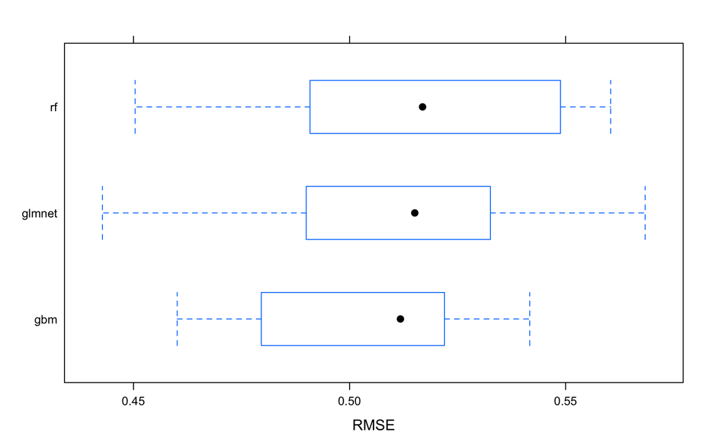

```r
# model comparison
resamp_a = resamples(attitude_m)
bwplot(resamp_a, metric = "RMSE")
```

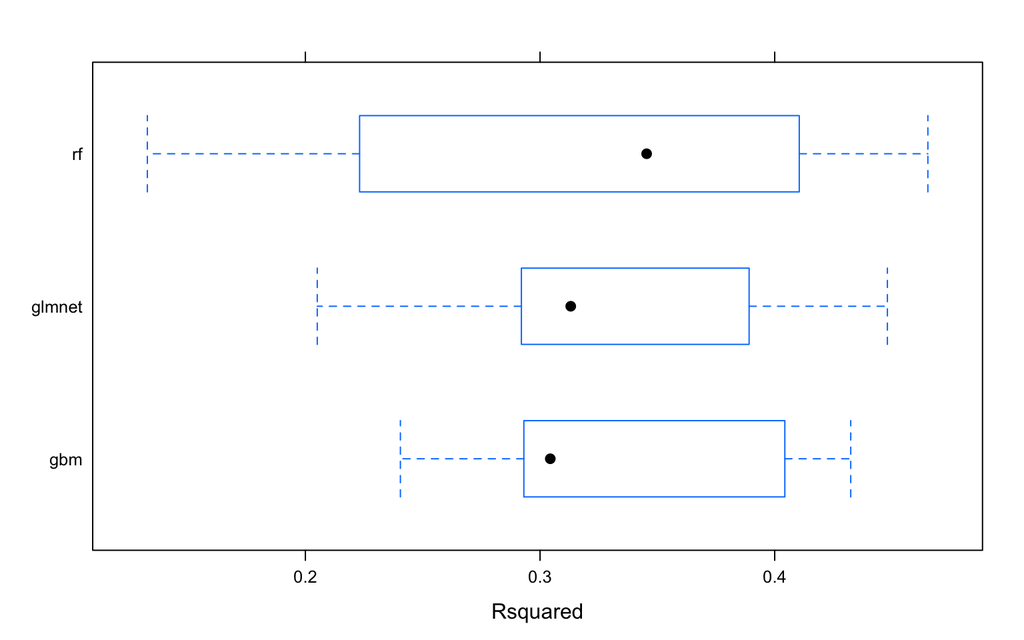

```r
bwplot(resamp_a, metric = "Rsquared")
```

Upon closer inspection, gradient boosted machine produces the lowest mean and median $RMSE$ as well as the highest mean $R^2$.

```r
summary(resamp_a)
```

```
Call:
summary.resamples(object = resamp_a)

Models: glmnet, rf, gbm
Number of resamples: 10

MAE
            Min.   1st Qu.    Median      Mean   3rd Qu.      Max. NA's
glmnet 0.3307726 0.3727001 0.3876482 0.3868094 0.4058582 0.4254364    0
rf     0.3347089 0.3723187 0.3855007 0.3867759 0.4019656 0.4500102    0
gbm    0.3540191 0.3767461 0.3841061 0.3836359 0.3913621 0.4026504    0

RMSE
            Min.   1st Qu.    Median      Mean   3rd Qu.      Max. NA's
glmnet 0.4428281 0.4927880 0.5150936 0.5110729 0.5309945 0.5683965    0
rf     0.4503915 0.4918139 0.5168916 0.5139458 0.5481647 0.5604222    0
gbm    0.4601262 0.4864651 0.5117700 0.5058205 0.5207379 0.5416844    0

Rsquared
            Min.   1st Qu.    Median      Mean   3rd Qu.      Max. NA's
glmnet 0.2050605 0.2955572 0.3130827 0.3297900 0.3831297 0.4480134    0
rf     0.1326575 0.2293060 0.3454218 0.3154692 0.4099830 0.4652672    0
gbm    0.2404878 0.2942632 0.3043635 0.3332037 0.3939871 0.4324019    0
```

Let’s look at the importance / relative influence of each variable for each model. All models share the same top 5 important variables, albiet assigning different values of importance. However, the top 19 important variables in elastic net and random forest overlap, whereas gradient boosted machine seems to diverge sharply from elastic net variable importance.

```r
# reorder relative importance of gbm to fit variable importance order of other algorithms
gbm_a = summary(attitude_m[[3]])
```

```r
first_a = rownames_to_column(varImp(attitude_m[[1]])$importance)$rowname
second_a = rownames_to_column(gbm_a)$rowname
reorder_a = match(first_a, second_a)

# get variable importance tibble
attitude_var_imp = tibble(
variable = names(df_fts[,-grep("data_sharing_attitudes",colnames(df_fts))]),
elastic_net = varImp(attitude_m[[1]])$importance$Overall,
random_forest = varImp(attitude_m[[2]])$importance$Overall,
gradient_boost = gbm_a[reorder_a,]$rel.inf
)

# output data table
datatable(attitude_var_imp)
```

|  | variable | elastic_net | random_forest | gradient_boost |
| --- | --- | --- | --- | --- |
| 1 | year | 2.7380474534982 | 5.80990222380332 | 1.0735283936926 |
| 2 | duration | 0 | 7.71181039777128 | 2.01452456648302 |
| 3 | activity | 0 | 0.401823772684213 | 0 |
| 4 | irg | 0 | 0.633417410063827 | 0 |
| 5 | funding_agency | 0 | 0.424510990251626 | 0 |
| 6 | num_requests | 3.05870003016369 | 6.47197863690934 | 2.72794909978224 |
| 7 | data_available | 0 | 0.622154951379085 | 0 |
| 8 | data_personal_website | 0 | 0.236682655445669 | 0 |
| 9 | data_prof_website | 0 | 0.350313425818237 | 0 |
| 10 | data_prof_archive | 0 | 0.425139134611504 | 0 |

[output cut: 127 more lines]

### Modeling data sharing behaviors

Below, I’m training models to predict data sharing **behaviors** using some popular algorithms in the machine learning space.

```r
behavior_m = list() #store trained models
behavior_p = list() #store predictions
behavior_v = list() #store validities

# set up parallelization
cores = detectCores()
registerDoParallel(cores)

for(i in seq_along(algo)) {
  # train models
  behavior_m[[algo[i]]] = train(
    data_sharing_behaviors ~ .,
    data = df_fts,
    method = algo[[i]],
    na.action = na.pass,
    trControl = trainControl(
      method = "cv",
      number = 10,
      verboseIter = T,
      allowParallel = T
    )
  )

  # predict on holdout
  behavior_p[[algo[i]]] = predict(behavior_m[[i]], test)
}
# clean up
registerDoSEQ()
```

The box-and-whisker plots show that elastic net gives the lowest median $RMSE$ and about the same $R^2$

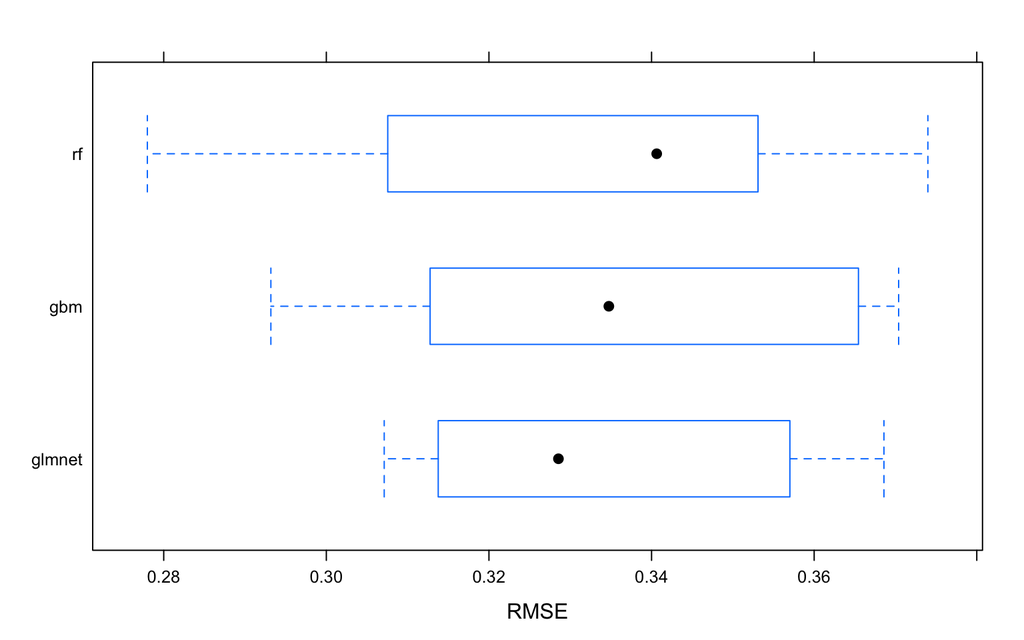

```r
# model comparison
resamp_b = resamples(behavior_m)
bwplot(resamp_b, metric = "RMSE")
```

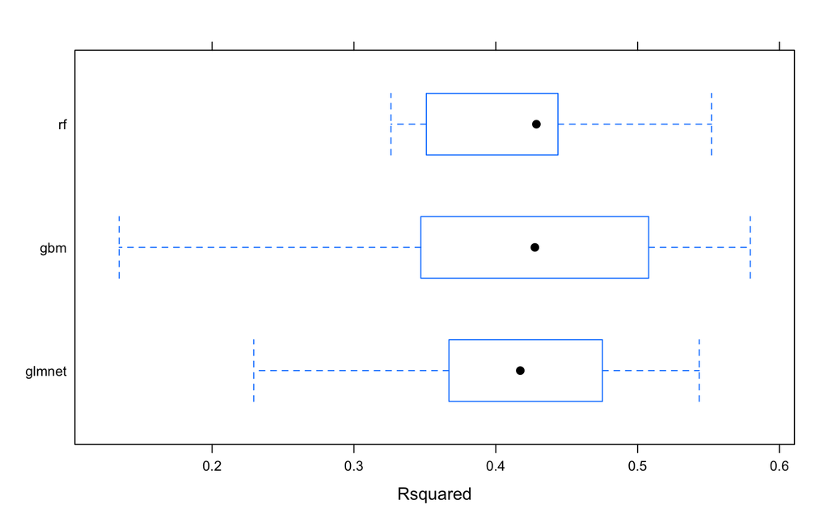

```r
bwplot(resamp_b, metric = "Rsquared")
```

It appears that random forst has the lowest mean $RMSE$ but the highest median. Elastic net has the lowest median $RMSE$. Random forest has the highest median and mean $R^2$.

```r
summary(resamp_b)
```

```
Call:
summary.resamples(object = resamp_b)

Models: glmnet, rf, gbm
Number of resamples: 10

MAE
            Min.   1st Qu.    Median      Mean   3rd Qu.      Max. NA's
glmnet 0.2328672 0.2403769 0.2498543 0.2502336 0.2592436 0.2712793    0
rf     0.2064395 0.2322074 0.2481796 0.2445988 0.2623853 0.2683764    0
gbm    0.2168553 0.2314218 0.2522101 0.2491268 0.2632409 0.2782831    0

RMSE
            Min.   1st Qu.    Median      Mean   3rd Qu.      Max. NA's
glmnet 0.3071197 0.3145097 0.3285469 0.3338264 0.3555450 0.3685807    0
rf     0.2779869 0.3104120 0.3406332 0.3329346 0.3530026 0.3739841    0
gbm    0.2931791 0.3136780 0.3347469 0.3333313 0.3588660 0.3703902    0

Rsquared
            Min.   1st Qu.    Median      Mean   3rd Qu.      Max. NA's
glmnet 0.2293456 0.3732561 0.4172671 0.4126590 0.4733567 0.5434232    0
rf     0.3261018 0.3525177 0.4286304 0.4198904 0.4417568 0.5520927    0
gbm    0.1344613 0.3493850 0.4275703 0.4083119 0.5049423 0.5794202    0
```

Let’s look at the importance / relative influence of each variable for each model. All models share the same top 4 important variables, albiet assigning different values of importance. Again, the top important variables in elastic net and random forest overlap, whereas gradient boosted machine seems to diverge from elastic net.

```r
# reorder relative importance of gbm to fit variable importance order of other algorithms
gbm_b = summary(behavior_m[[3]])
```

```r
first_b = rownames_to_column(varImp(behavior_m[[1]])$importance)$rowname
second_b = rownames_to_column(gbm_b)$rowname
reorder_b = match(first_b, second_b)

# get variable importance tibble
behavior_var_imp = tibble(
variable = names(df_fts[,-grep("data_sharing_behaviors",colnames(df_fts))]),
elastic_net = varImp(behavior_m[[1]])$importance$Overall,
random_forest = varImp(behavior_m[[2]])$importance$Overall,
gradient_boost = gbm_b[reorder_b,]$rel.inf
)

# output data table
datatable(behavior_var_imp)
```

|  | variable | elastic_net | random_forest | gradient_boost |
| --- | --- | --- | --- | --- |
| 1 | year | 0 | 4.63253698396212 | 0.572463483493505 |
| 2 | duration | 0 | 5.3217791684577 | 0 |
| 3 | activity | 0 | 0.59425157488765 | 0 |
| 4 | irg | 6.25463897284226 | 1.41369047038303 | 1.67549413859899 |
| 5 | funding_agency | 0 | 0.401356547887917 | 0 |
| 6 | num_requests | 2.18490176441488 | 6.64641246674574 | 2.625050025265 |
| 7 | data_available | 0 | 6.37468315219751 | 3.53632379469963 |
| 8 | data_personal_website | 0 | 0.259538440038793 | 0 |
| 9 | data_prof_website | 4.78373875484256 | 0.619165423655927 | 0.257363974608341 |
| 10 | data_prof_archive | 22.7008982025628 | 5.37250907197629 | 7.9719966184955 |

[output cut: 127 more lines]

## Machine learning conclusions

### Modeling

It is noted that modeling process assumes linearity, even though interactions between variables could very well be present. Another alternative is modeling interactions between all variables to explroe interactions a little more. It might be a better reflection of the complexities that go into deciding whether to share data. However, to model interactions between all variables in this dataset would take tremendous computational effort. Paired combinations among variables is can be calculated by $\frac{n!}{k!(k - n)!}$, which in this case, with 139 features, would be an extra 9591 variables to include in the model.

### Variable importance

Since GBM models performed the best for data sharing attitudes, I wanted to explore the relationships between the top 5 variables that exerted the most influence in this class of models. The variables are:

Given the correlation between data sharing behaviors and attitudes, it makes sense that behaviors is the most important variable for attitudes. Interestingly, it seems as though fears of data misinterpretation and data scooping are also important regarding data sharing attitudes. These fears would likely lead to not sharing/posting data. Number of grants received also seemed to be an important predictor. Since we the dataset only had information on NSF and NIH agencies, and since these agencies require public and open practices, it makes sense this would be a significant predictor. What also seemed important to attitudes was whether other researchers posted their data.

Similarly, data sharing attitudes was the most important predictor of overall data sharing behaviors. What was also interesting was that the region the PI was in and being in the sociology discipline was important for behaviors. There are most likely culture/climate on specific data sharing practices in the northeast region of the US as well as within sociology. Of course, uploading grant data to an archive predicted overall data sharing behaviors within one’s career. It might be useful to look into whether federal grants impact the data sharing frequency and data sharing attitudes. It seems likely that more federal grants could shape open science practices by merely requiring them.

# Visualization

## Data sharing attitudes

These are the relationships between the top 5 important predictors of data sharing attitudes.

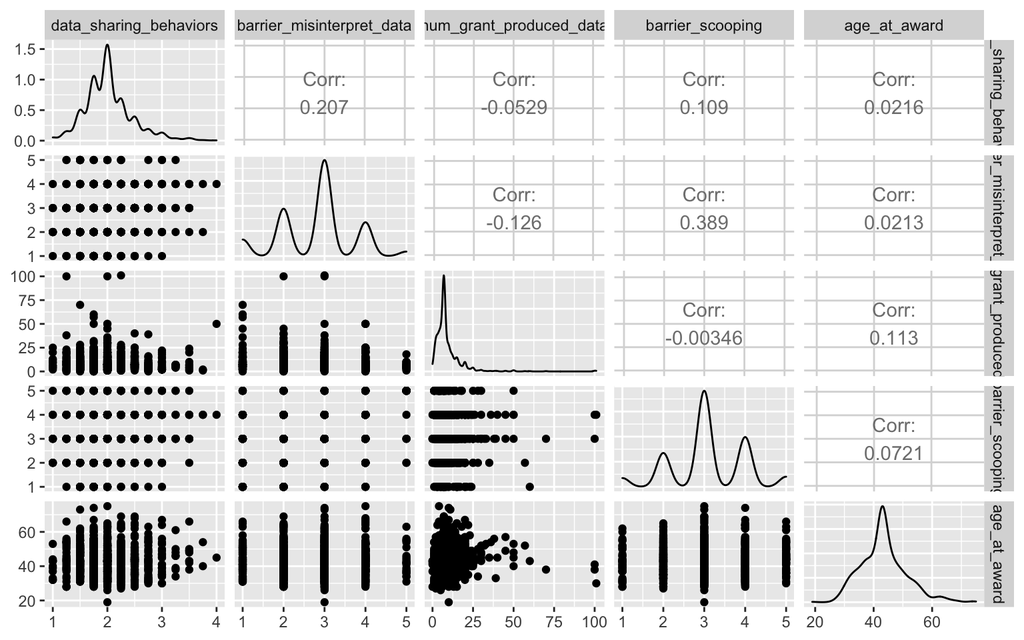

```r
df_fts %>%
  select(
    data_sharing_behaviors,
    barrier_misinterpret_data,
    num_grant_produced_data,
    barrier_scooping,
    age_at_award
  ) %>%
  ggpairs()
```

## Data sharing behaviors

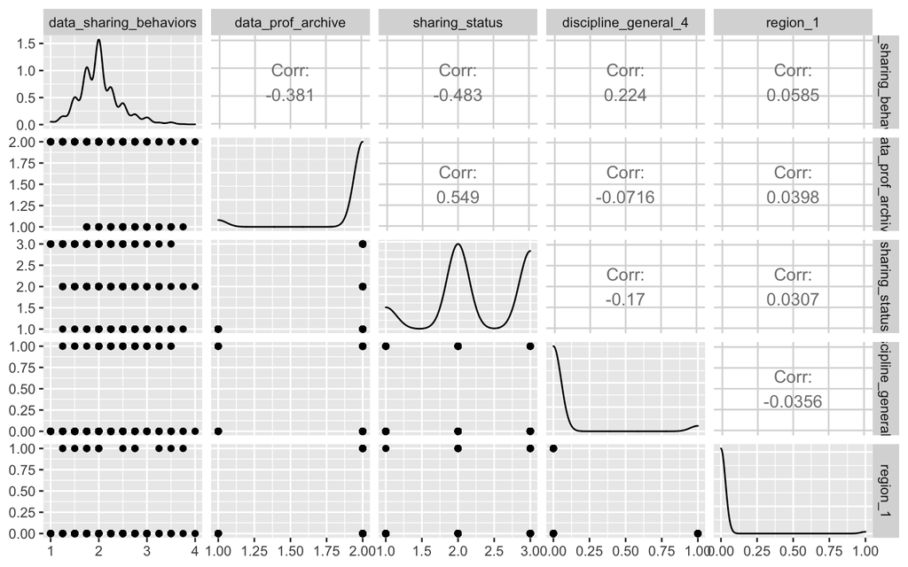

```r
df_fts %>%
  select(
    data_sharing_behaviors,
    data_prof_archive,
    sharing_status,
    discipline_general_4,
    region_1
  ) %>%
  ggpairs()
```

There are several vavriables that appear categorical, and thus, alternative kinds of correlations are needed to uncover these relationships (e.g., tetrachoric, point-biserial, polychoric, etc.).